# lecture-01-introduction

## M303 Marketing Research

[figure not shown]

FALL 2026

M303

Marketing Research

Introduction to Marketing Research

## Where we are

01**Orient**

Meet one another and understand how the course will work.

02**Frame**

See how M303 covers the full marketing-research process.

03**Begin**

Ask why marketing decisions need evidence rather than intuition alone.

## Learning Objectives

01**Define business and marketing intelligence**

Understand how organizations connect information to decision makers.

02**Define marketing research**

Explain how research links the firm and the marketplace through information.

03**Recognize its importance**

Understand why marketing decisions require evidence, not guesses alone.

## Opening diagnostic

CHOOSE ONE

**Which statement best describes marketing research?**

A

It is another name for analyzing data.

B

It connects a firm and its market through information.

C

It begins only after a manager has selected a solution.

**B**Marketing research covers the full path from framing the problem to collecting and analyzing evidence and recommending action.

## Outline

01**Introductions**

Get acquainted and establish how we will work together.

02**Course overview**

Expectations, assessments, materials, and the term project.

03**Marketing research**

Why firms need evidence—and what research contributes.

## Your instructor

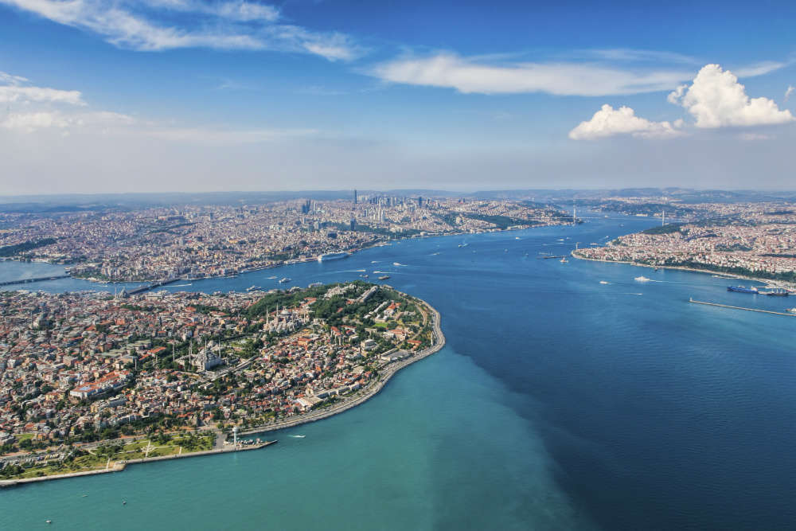

**FROM [ISTANBUL](https://www.youtube.com/watch?v=7A1q7v4btbk&pp=ygUMaXN0YW5idWwgdGh5), [TÜRKİYE](https://www.youtube.com/watch?v=QhWw73jMAg0&pp=ygULdHVya2l5ZSB0aHk%3D)**TripAdvisor's most popular travel destination in 2014

Koray Cosguner (Core - Eye)

PROFESSIONAL BACKGROUND

Ph.D. in Marketing, Washington University in St. Louis  
M.A. in Economics, Koç University, Türkiye  
B.S. in Engineering, Bilkent University, Türkiye

RESEARCH

Modeling and analyzing marketing agents' behaviors through the use of statistical and econometric models.

*Marketing Science* · *Management Science* · *Journal of Marketing Research*

CONTACT

kcosgun@iu.edu · (812) 778-0074  
Office hours by appointment via Zoom  
Email me to schedule · iu.zoom.us/my/kcosguner

## Your information

INFORMATION SHEET ON CANVAS

- First and last name
- Nickname or preferred form of address
- Pronunciation, if helpful
- Major and year
- Marketing research expertise or relevant experience
- Expectations for the course
- Something interesting about yourself

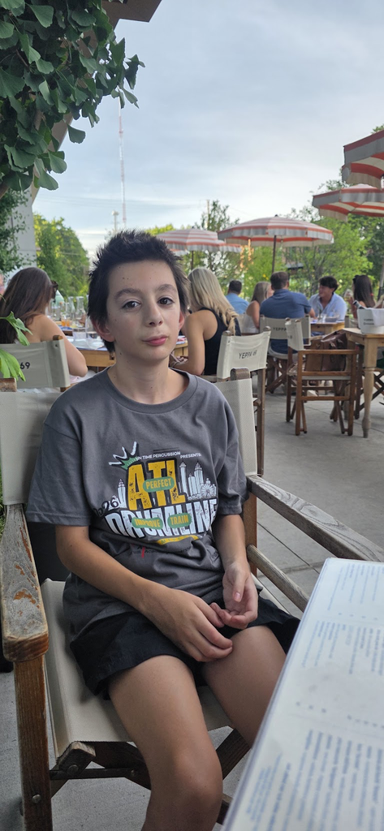

SOMETHING INTERESTING ABOUT ME**Yusuf (13)**

[figure not shown]

SOMETHING INTERESTING ABOUT ME**Hakan (7)**

## Course outline

Problem  
formulation

Preliminary stages of marketing research

Research  
design

Choose an appropriate research design

Data  
collection

Secondary data  
Primary data  
Sampling

Data analysis &  
recommendations

**Fundamentals of data analysis**  
Preparation of data for analysis  
Descriptive statistics, simple tabulations, and cross-tabulations  
Hypothesis testing  
Correlation and regression analysis

## Marketing Research vs. Analytics

01Problem formulation &  
research design

→

02Data  
collection

→

03Data analysis &  
recommendation

**M303 · MARKETING RESEARCH**The entire research process

**M346 · MARKETING ANALYTICS**

## What will we do?

THEORY

**Lectures**Learning through lectures, discussion, and in-class demonstrations

**Lecture notes**Core concepts and frameworks

**Exams**Assess understanding of core concepts

PRACTICE

**Practice assignments**Four applied data-analysis assignments in the second half of the course

**Term project**Conduct a study and present recommendations

**In and out of class**Discussions, data demonstrations, exercises, and assignments

## How your grade is built

Three exams establish the foundation; practice assignments and the term project turn knowledge into skill.

**Exams**3 × 20%**60%**

**Practice assignments**4 × 5% · Data-analysis half**20%**

**Term project**Report 10% + Presentation 10%**20%**

**Total****100%**

## Course expectations

3

EXAMS

**Non-cumulative**

Multiple-choice and true/false questions

4

PRACTICE ASSIGNMENTS

**Applied data analysis**

Four assignments in the second half of the course. Instructions and required data files will be posted on Canvas.

1

TERM PROJECT

**Integrated research project**

Group project; groups finalized September 3; includes a written report and presentation.

**In-class practice:** we will work through research problems together.**Exam support:** a study guide will be provided before each exam.**Project reminders:** Canvas reminders will follow the suggested syllabus timeline; they are not separate graded assignments.

## The term project follows the full research journey

A team project that begins with a managerial decision and ends with an evidence-based recommendation.

01

### Frame

Select a firm or context and develop four research questions.

02

### Collect

Design a short survey and gather 70–80 responses.

03

### Analyze

Match each question to an appropriate statistical analysis.

04

### Recommend

Translate findings into managerial recommendations.

DELIVERABLES

**Report 10% + Presentation 10%**

**Zoom consultations · Dec 1 & 3**Presentations · Dec 8 & 10  
15–20 minutes per team, including 1–2 minutes for Q&A

## Course materials

NO REQUIRED TEXTBOOK

Everything you need will live in one place.

Canvas will contain lecture notes, instructions, and required data files.

WEB TOOLS

**Instructor-designed analysis tools**

Hypothesis testing · Regression · Conjoint analysis

koraycosguner.github.io/tools.html

Excel and R are optional.

Examples and demonstrations will be presented in class.

## The use of GenAI

AI

A LEARNING TOOL

**Use it transparently—and keep the thinking yours.**

01

You are encouraged to use generative artificial intelligence (GenAI) as a tool to assist in your learning process, including assignments.

02

Always acknowledge GenAI use in your assignments and cite it appropriately. Do not present AI-generated work as your own.

03

Use GenAI to supplement—not replace—your critical thinking and problem-solving. You are responsible for inaccurate, biased, offensive, or otherwise unethical content you submit.

04

**The exception is exams:** GenAI use is prohibited during exams. I will also collaborate with GenAI to develop course content, including readings, datasets, and research exercises.

## Important dates

Practice assignments begin with data analysis; project checkpoints are ungraded reminders.

SEPTEMBER

**Exam 1 · Sep 22**Groups finalized · Sep 3

OCTOBER

**Exam 2 · Oct 22**Practice Assignment 1 · Oct 15

NOVEMBER

**Exam 3 · Nov 19**Practice Assignment 2 · Nov 3  
Practice Assignment 3 · Nov 12

DECEMBER

**Presentations · Dec 8 & 10**Zoom consultations · Dec 1 & 3  
Practice Assignment 4 · Dec 3  
Report/slides · Dec 8

Please contact me as early as possible about documented exam conflicts.

No technology during class sessions.

## Introduction to Marketing Research

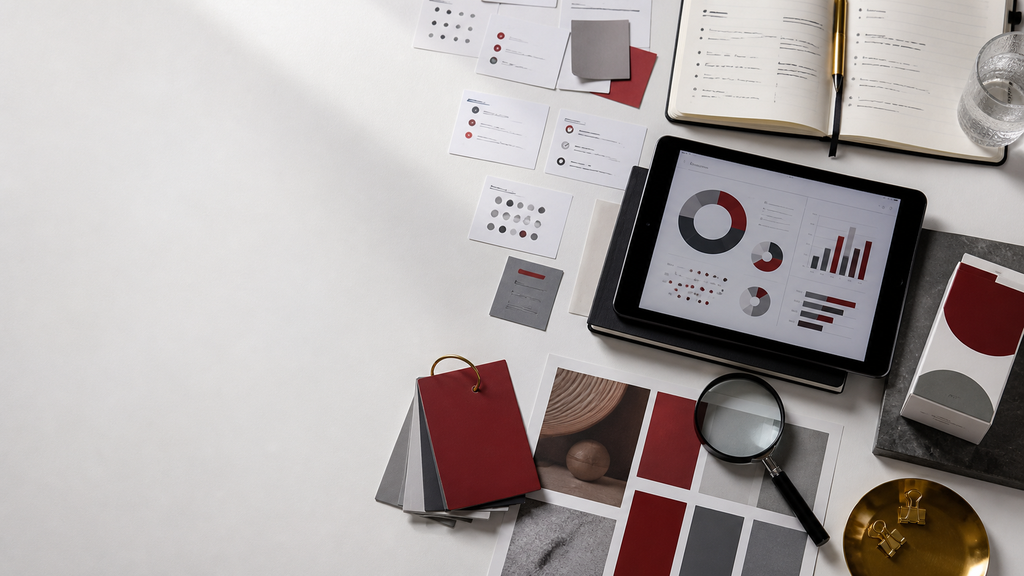

LECTURE 01

Introduction to  
Marketing Research

Why firms need research.

## Why do we need marketing research?

[figure not shown]

or

Have you heard this story before?

NEW COKE · 1985

**The evidence looked persuasive.**Coca-Cola spent $4 million and taste-tested the new soda with nearly 200,000 customers. New Coke beat both the original Coke and Pepsi in blind taste tests.

**But the study asked the wrong question.**Tasters were not told that New Coke would replace the original formula.

**Taste was not everything.**Consumers identified with the old brand and wanted to retain “The Real Thing.” Launched April 23, it was withdrawn by July.

How would you design a better study?

## Netflix–Qwikster

[figure not shown]

Have you heard this story?

2011 · MARKET VALUE: $16 BILLION

A strategic split customers did not ask for

Netflix proposed spinning off its core DVD-by-mail service as Qwikster while keeping streaming under the Netflix brand.

**Customers dropped the service in droves.**By year's end, Netflix's market capitalization was less than $4 billion.

## Why not just make educated guesses?

“

> I think there is a world market for maybe five computers.

Thomas Watson · IBM chairman · 1943

## Educated guesses

“

> Interesting and well formed, but in order to earn better than a C, the idea must be feasible.

Yale professor · feedback on Fred Smith’s paper proposing what became Federal Express

## Educated guesses

> Television won't be able to hold on to any market it captures after the first six months. People will soon get tired of staring at a plywood box every night.

**Darryl Zanuck**  
20th Century Fox Films

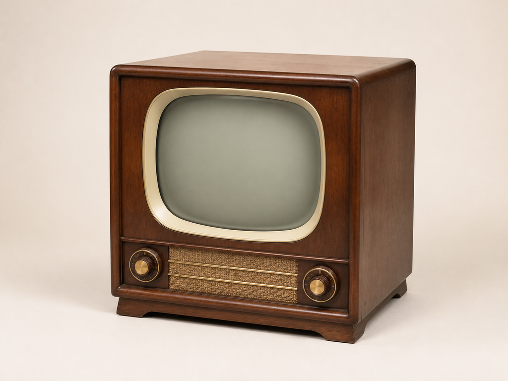

## Educated guesses

> With over fifty foreign cars already on sale here, the Japanese auto industry isn’t likely to carve out a big slice of the U.S. market for itself.

**Business Week · 1968**

> Everything that can be invented has been invented.

**Charles Duell · Commissioner, U.S. Office of Patents · 1899**

> There is little reason for any individual to have a computer in their home.

**Ken Olsen · DEC president and founder · 1977**

## Why not just use managerial intuition?

01

People are poor at learning from experience.

02

People have poor intuitive senses for the **dollar value** of information.

03

People process information with limited capacity and predictable biases.

Managers are people!

## Why is managerial decision-making difficult?

Managerial decisions are difficult because they are…

**Risky.**Why?

**Outcomes are uncertain.**

How do we reduce risk in decision making?

Information.

## What is business intelligence?

Multiple sources

→

BUSINESS INTELLIGENCE

The ability to access data from multiple sources within an organization and deliver it to business users for analysis.

→

**Business users**Analysis

## How business intelligence works

Business Intelligence

Financial IntelligenceManagement IntelligenceMarketing IntelligenceAccounting Intelligence…

Marketing ResearchCustomer Relationship Marketing / Database Marketing

Primary SourcesSecondary SourcesStandardized Sources

PROVIDE DATA ON

ProspectsCustomersCompetitionProducts / Markets

## What is marketing intelligence?

Market intelligence (MI) is the process of acquiring and analyzing information in order to…

01

Understand the market—both existing and potential customers.

02

Determine the market's current and future needs, preferences, attitudes, and behavior.

03

Assess changes in the business environment that may affect the size and nature of the market in the future.

— Cornish, S. L.

## Why do we need marketing intelligence?

1. Producers have little direct contact with consumers because of geographical distance and channel layers.
2. Channel partners have limited knowledge of customer attitudes, preferences, and changing tastes.
3. Firms need to monitor competitors and market changes.
4. Management goals involve sales targets and market-share achievement.
5. Firms need to identify successful new-product developments early to support growth and revenue maximization while balancing costs and prices.
6. Because the future is uncertain, firms need to look at least five to ten years ahead.

## What is marketing research?

DEFINITION

Marketing research is all activities that provide information to guide marketing decisions in the marketplace.

→

SHORTER

Marketing research is the link between the firm and the market through information.

Adapted from Sudman & Blair (1998, p. 6)

## Marketing research in action

SCENARIO

A food-delivery app is considering a membership program for students in Bloomington.

The question is not simply whether students like the idea, but what to launch, for whom, and at what price.

DECISION

**Choose the plan, target, price, and message.**

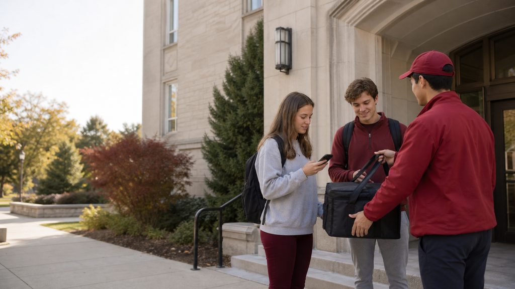

### Listen

Interview students about ordering occasions and pain points.

### Measure

Survey awareness, delivery-fee sensitivity, and desired benefits.

### Test

Compare lower fees, pickup rewards, and group-order perks.

### Recommend

**Illustrative result:** predictable delivery savings outperform pickup rewards. Pilot a low-fee plan with group-order credits.

## In-class exercise

WORK IN GROUPS OF THREE

A food-delivery app is considering a membership program for students in Bloomington.

What marketing research studies should the company conduct before launch?

## Possible studies

What studies would help answer the launch decision?

01

Surveys of student satisfaction, dissatisfaction, and complaints

02

Ordering-pattern surveys to assess the app's competitive position

03

Experiments evaluating alternative membership prices

04

Ordering-data analysis to estimate acceptance of new benefits

05

New-product concept and market testing

06

Delivery-zone and location analysis

07

Studies of television, social, and local advertising effectiveness

08

Testing alternative app and offer layouts

09

Lifestyle research to anticipate changing student needs

10

Post-launch satisfaction and retention tracking

## Course outline

Problem  
formulation

Preliminary stages of marketing research

Research  
design

Choose an appropriate research design

Data  
collection

Secondary data  
Primary data  
Sampling

Data analysis &  
recommendations

**Fundamentals of data analysis**  
Preparation of data for analysis  
Descriptive statistics, simple tabulations, and cross-tabulations  
Hypothesis testing  
Correlation and regression analysis

## Before you leave

Make sure you submit the information sheet on Canvas before next class.

Anything still unclear? If so, please shoot me an email so we can clarify it next class.

First and last nameNickname or preferred form of addressPronunciation, if helpfulMajor and yearMarketing research expertise or relevant experienceExpectations for the courseSomething interesting about yourself

## To sum up

01

**Business intelligence**

Connects business users with data.

02

**Marketing intelligence**

Acquires and analyzes marketing data to improve decisions.

03

**Marketing research**

Links the firm and the market through information.

**Firms do marketing research for a reason.**If not, they might fail miserably—and educated guesses can be very misleading.

If anything is unclear, shoot me an email so we can clarify it next class.

## Next class

COMING NEXT

Marketing Research Process  
and Problem Formulation

How do we turn a managerial problem into a researchable question?